# Praca Domowa 3

Patryk Rakus, Malwina Wojewoda

23 11 2021

# Eksperyment 1

Eksperyment ten ma na celu pokazać, że odczytywanie i porównywanie wartości ze słupków jest zdecydowanie łatwiejsze, gdy słupki zaczynają się od tego samego miejsca i porównać wystarczy wysokość miejsca gdzie słupek się kończy, a nie jego długość.

## Wykresy

### Wykres 1

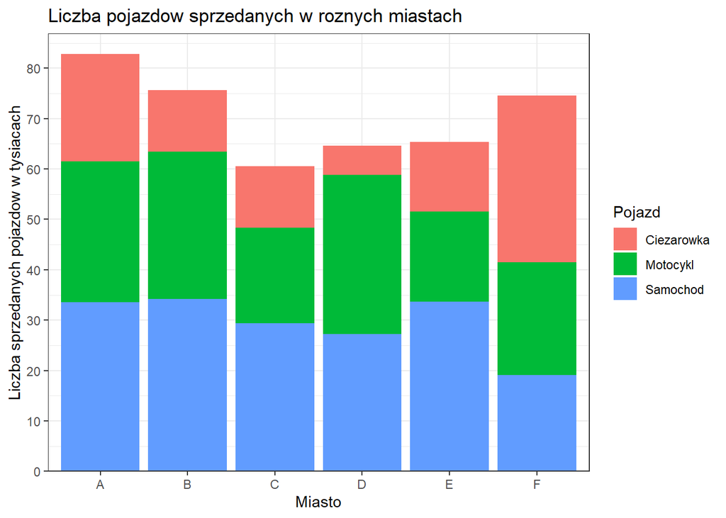

### Wykres 2

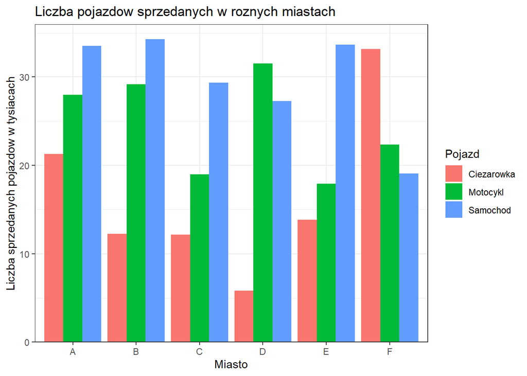

## Pytania i odpowiedzi ankietowanych

## Pytania

Dla obu wykresów zadano te same pytania:

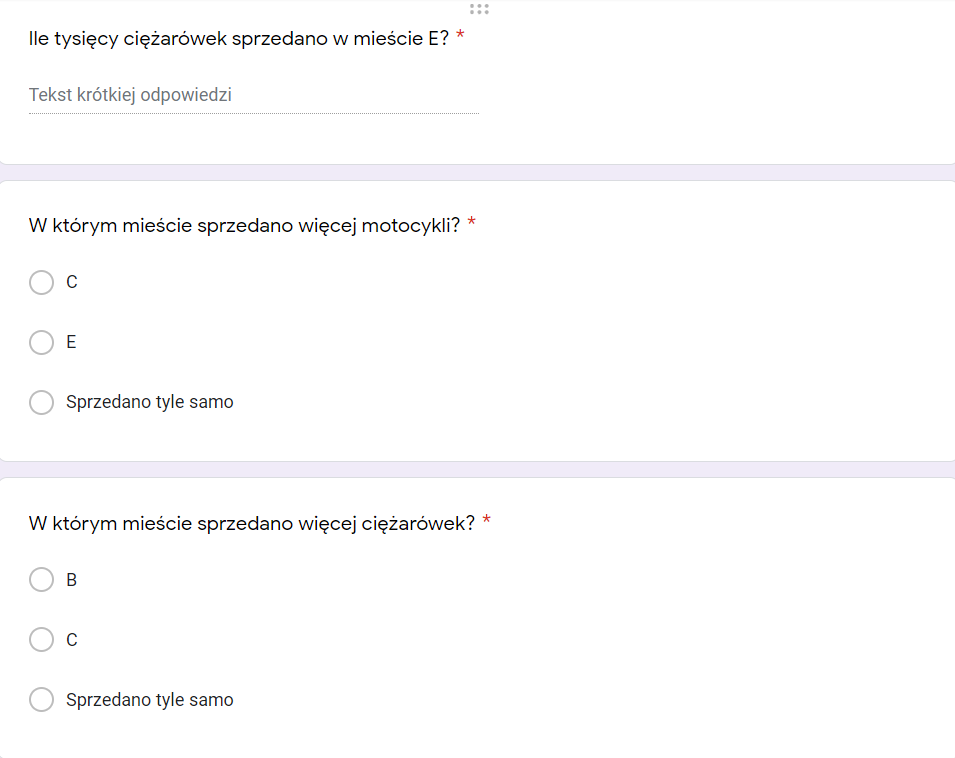

## Odpowiedzi

### W którym mieście sprzedano więcej motocykli?

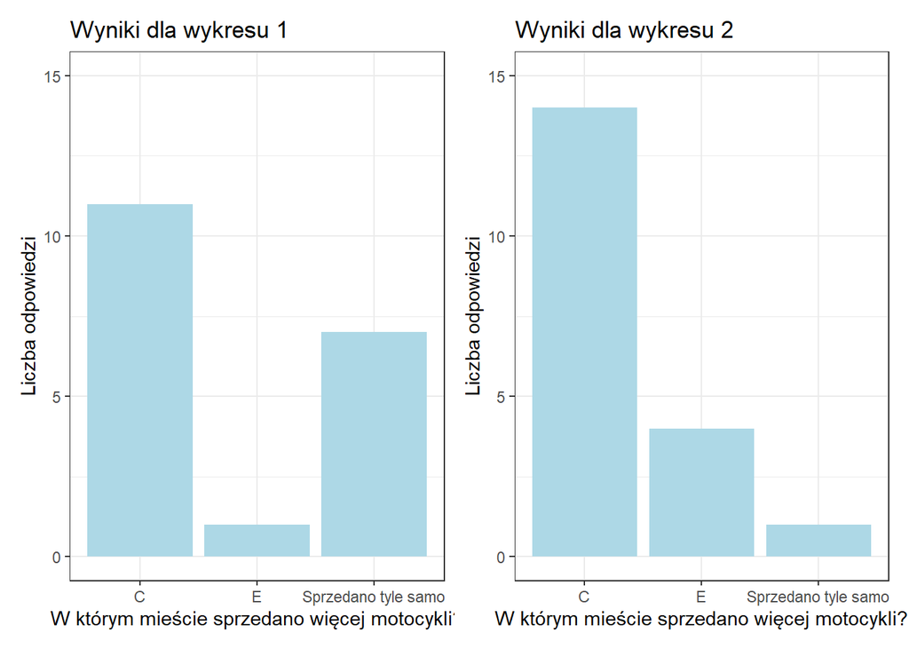

Poprawną odpowiedzią jest “C”. W tym przypadku zdecydowanie widać przewagę wykresu 2. W momencie gdy dla wykresu 1 ankietowani mieli problem ze stwierdzeniem, czy wartość jest większa czy równa, dla wykresu 2 zdecydowana większość potrafiła bezproblematycznie wybrać dobrą odpowiedź.

### W którym mieście sprzedano więcej ciężarówek?

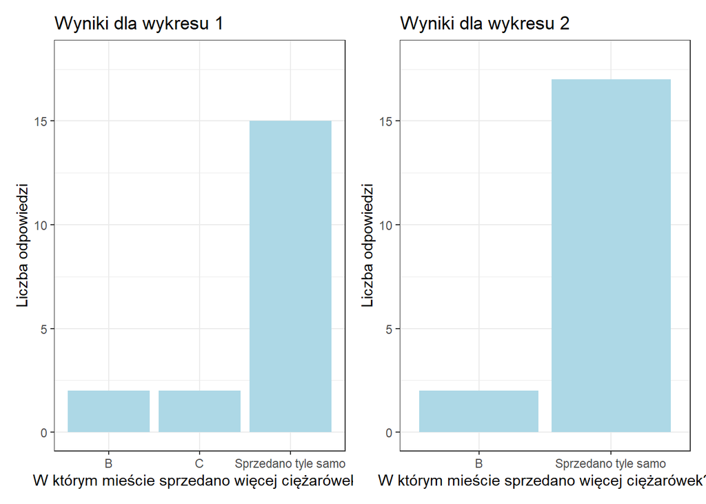

Poprawną odpowiedzią jest “Sprzedano tyle samo”. Wyniki są podobne lecz tutaj ankietowani, którzy dla wykresu 1 błędnie odpowiedzieli “C”, odpowiedzieli dla wykresu 2 poprawnie.

### Ile sprzedano ciężarówek w mieście E?

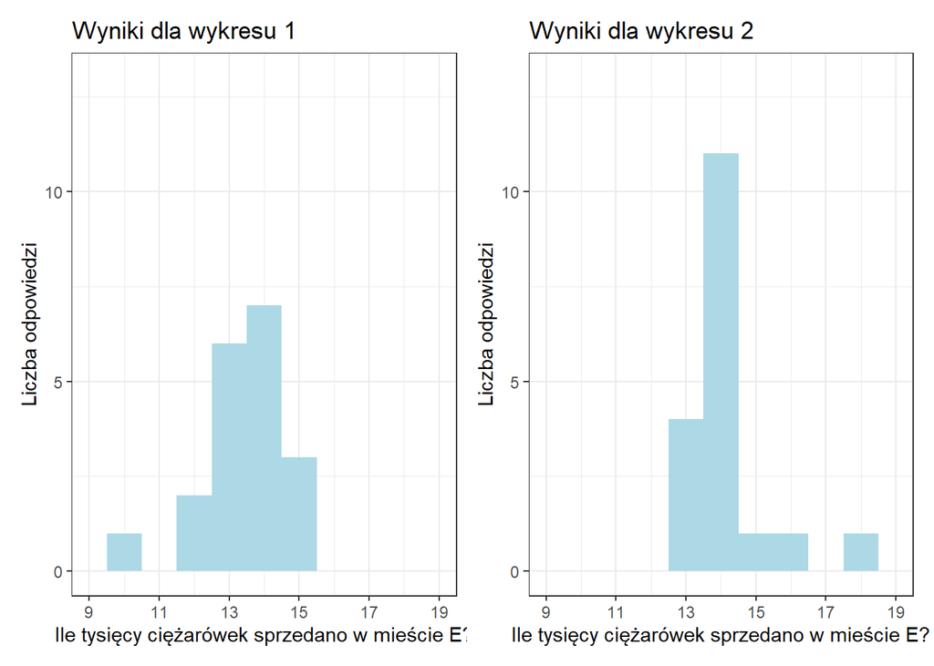

Poprawną odpowiedzią jest 14. To pytanie najlepiej ukazuje jak problematyczne może być odczytanie poprawnej wartości na wykresie 1, w porównaniu z wykresem 2.

# Eksperyment 2

Celem tego eksperymentu jest sprawdzenie czy faktycznie dużo trudniejsze jest odczytywanie kątów, czyli co za tym idzie danych z wykresów kołowych. W tym celu ankietowani zostali poproszeni o odpowiedzenie na 3 te same pytania odnośnie wykresu kołowego w 3D, zwykłego wykresu kołowego oraz wykresu słupkowego, posortowanego według wartości, który miał posłużyć jako najbardziej czytelny, kontrolny. Mimo, że wszystkie 3 wykresy bazują na tych samych danych, zmienione zostały nazwy reprezentujące wartości, aby sprawiały wrażenie, że nie są ze sobą powiązane. Celem tego było,żeby ankietowany nie sugerował się poprzednimi odpowiedziami.

## Wykresy

Wykres 1

Wykres 2

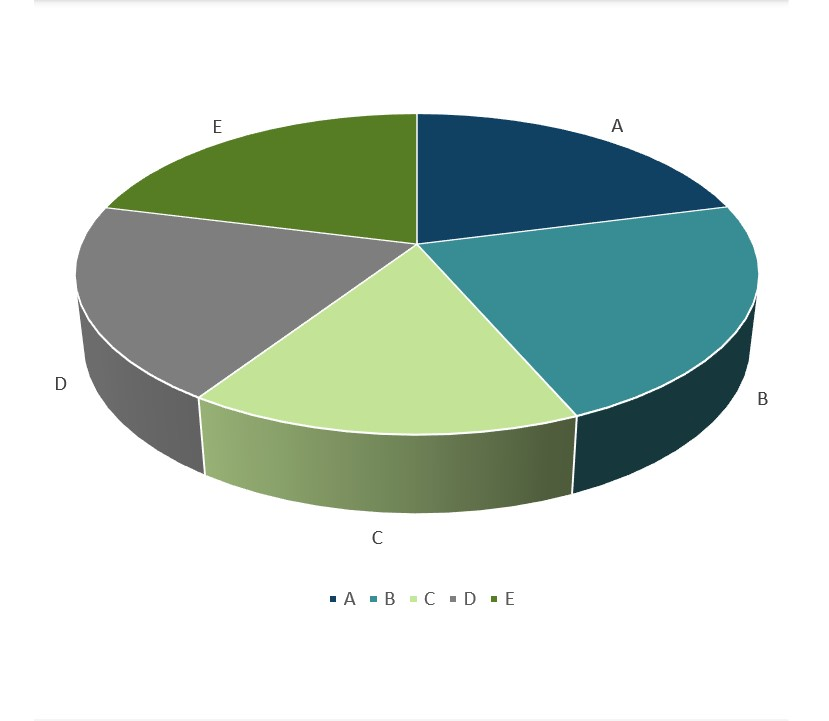

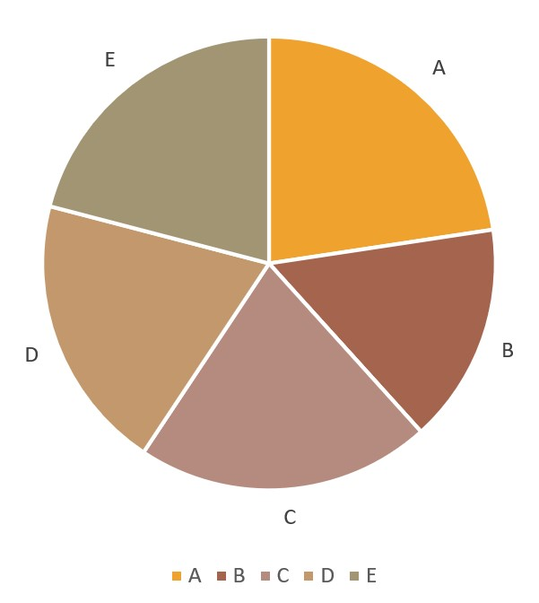

Wykres 3

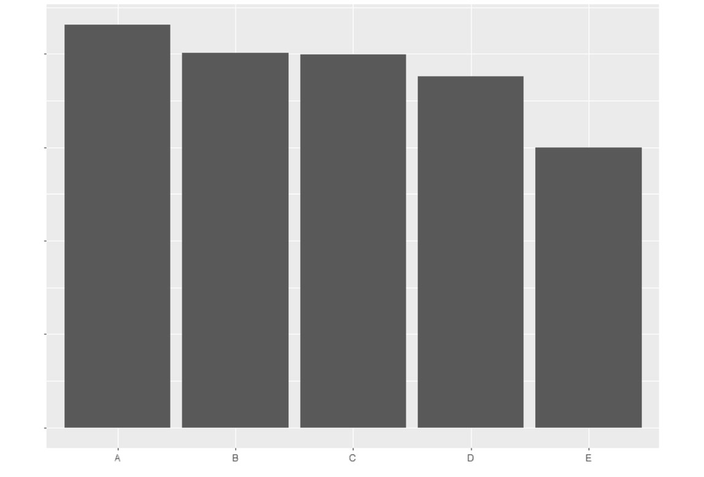

## Pytania i odpowiedzi ankietowanych

### Pytanie 1

Pierwsze pytanie było następujące:

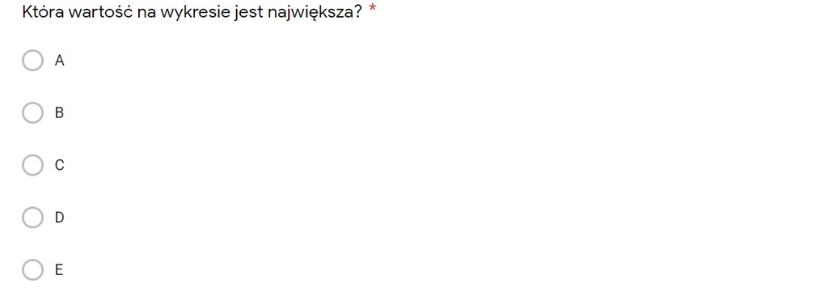

Odpowiedzi:

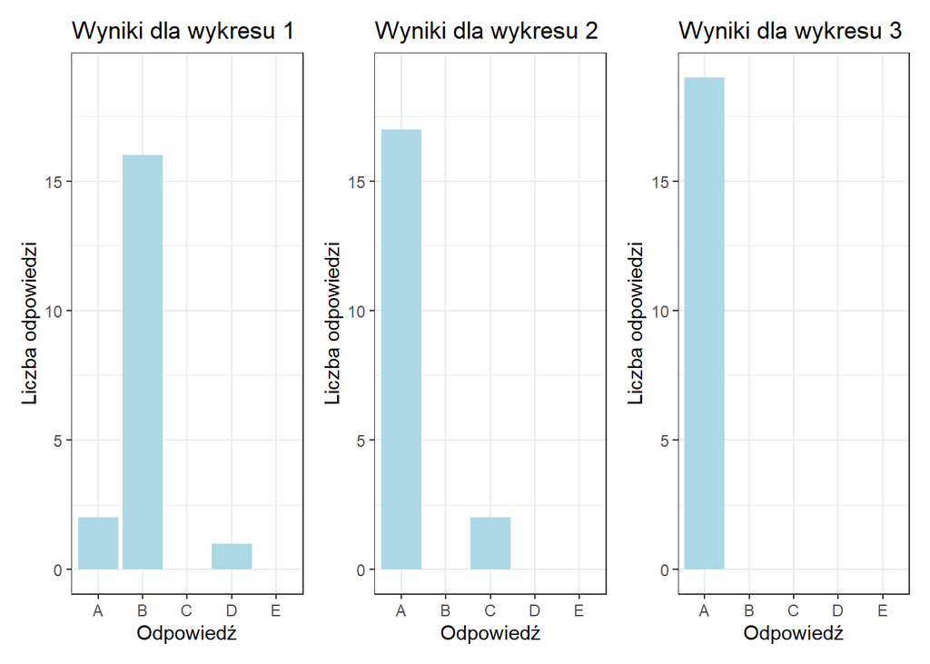

Dla wykresu pierwszego poprawna odpowiedź to “B”. Widać, że zdecydowana większość (16/19) ankietowanych poprawnie odczytało tę informację w wykresu. Odrobinę lepiej wypadło to w przypadku zwykłego wykresu kołowego. Tu pomyliły się tylko 2 osoby. Jak można się było spodziewać, z wykresu słupkowego wszyscy odczytali dane poprawnie.

### Pytanie 2

Następne pytanie było następujące:

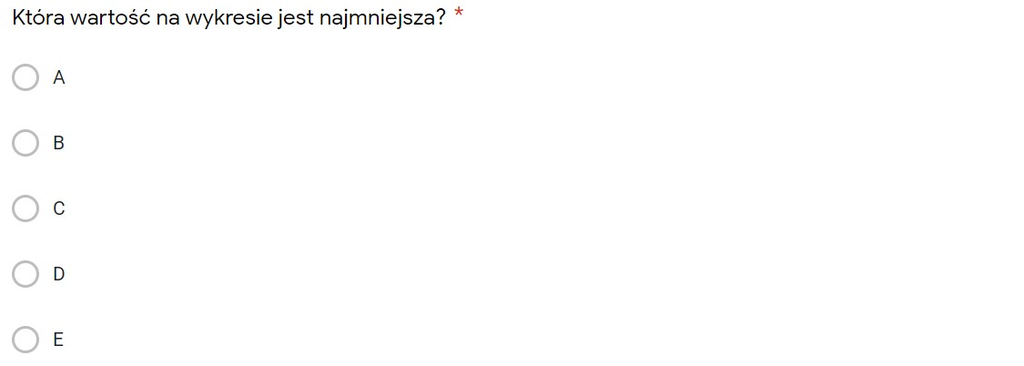

Odpowiedzi:

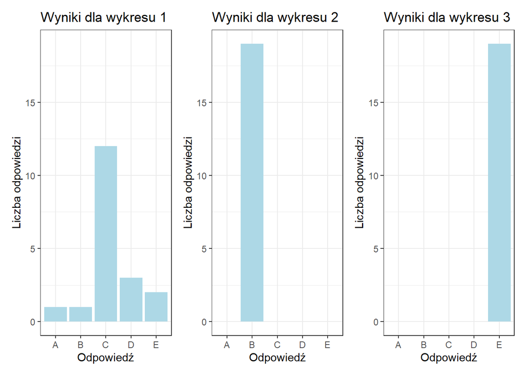

Na wykresie 1. poprawną odpowiedzią jest “C”. Wskazało ją 63,2% ankietowanych. Widać też, że pozostałe odpowiedzi rozłożyły się dość równomiernie, co może wskazywać na to, że ankietowani mieli duże wątpliwości co wybrać. Co ciekawe, w tym przypadku wszyscy ankietowani poprawnie wybrali wartość z wykresu kołowego. Oczywiście nie mieli też żadnych problemów z odczytaniem wykresu słupkowego.

### Pytanie 3

Ostatnie pytanie było brzmiało:

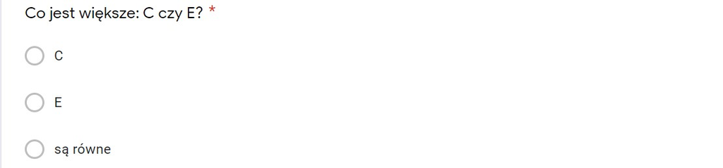

Odpowiedzi:

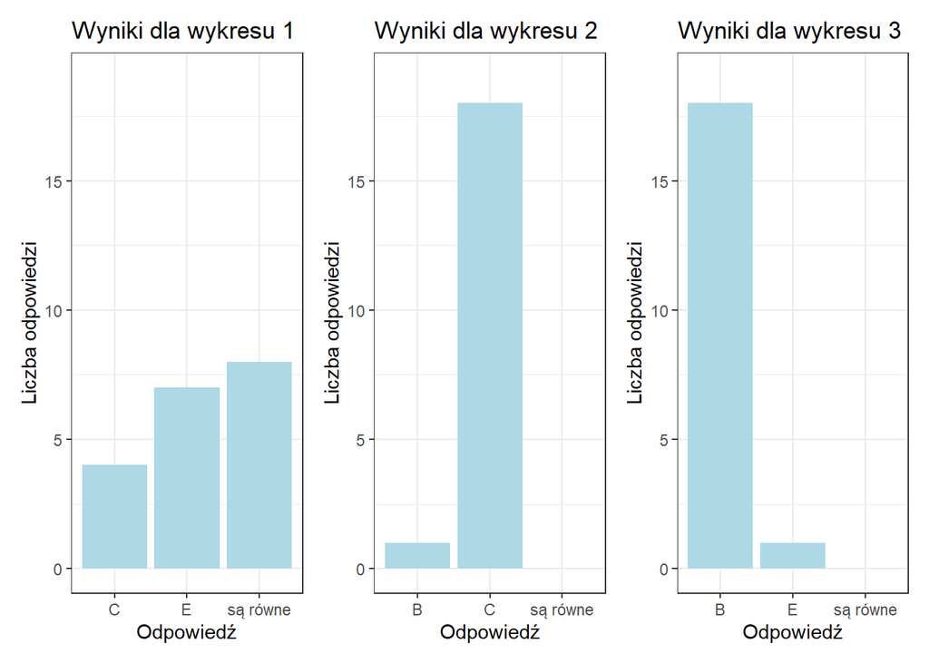

Na pierwszym wykresie poprawną odpowiedzią jest “E”, którą wskazało tylko 7 na 19 osób. Zdecydowanie mniej problemów sprawiło odczytanie tej informacji z wykresu kołowego, nie udało się to tylko jednej osobie. Także w przypadku wykresu słupkowego jedna osoba odpowiedziała niepoprawnie, co trudno uzasadnić.

## Podsumowanie

Z analizy odpowiedzi ankietowanych wynika, że odczytywanie infromacji z wykresu kołowego w 3D sprawia o wiele więcej problemów niż odczytanie ze zwykłego wykresu kołowego. W przypadku niego większość badanych radzi sobie dobrze, chociaż na pewno nie jest to tak szybkie i oczywiste jak na intuicyjnym wykresie słupkowym z uporządkowanymi danymi. Przedstawione na wykresach wartości były dość zbliżone, dlatego można wyciągnąć wniosek, że jeśli dane byłyby bardziej zróżnicowane to ankietowani nie mieliby większych problemów z porównaniem danych na wykresie kołowym, jednak wymaga to na pewno większego wysiłku ze strony odczytującego. Wykresy kołowe w 3D tworzą iluzję opytczną i najbardziej zakrzywiają proporcje, dlatego nie warto z nich korzystać. Należy jednak wziąc pod uwagę, że niektóre wykresy słupkowe są lepsze od innych. Porównywanie słupków, które zaczynają się od róznych liczb jest bardziej problematyczne, niż gdy zaczynają się od tej samej liczby. Powyższe eksperymenty udawadniają, że dobre praktyki robienia wykresów mają znaczenie, gdy chcemy sprawić, aby nasz wykres był czytelny.